# Epi Machine Learning Assignment 5

Sydney Ng (uni: sn2863)

Due February 16, 2021 by 5:30 PM

```r
alc <- read_csv("./alcohol_use.csv") %>%
  select(-X1) %>%
  mutate(alc_consumption = factor(alc_consumption, levels = c("NotCurrentUse", "CurrentUse")))

# splitting into testing and training 80/20
set.seed(1234)

train.indices <-
  createDataPartition(y = alc$alc_consumption, p=0.8, list=FALSE) %>%
  as.vector()

training <- alc[train.indices,]
testing <- alc[-train.indices,]

# storing the outcome
alc_consumption_train <- training$alc_consumption
alc_consumption_test <- testing$alc_consumption

# model.matrix shortcut to remove outcome variable from matrix
x.train <- model.matrix(alc_consumption~., training)[,-1]
x.test <- model.matrix(alc_consumption~., testing)[,-1]
```

```r
alc_features <- alc %>% select(-alc_consumption)

# Checking means and SDs to determine if scaling is necessary
colMeans(alc_features, na.rm=TRUE)
```

```
##       neurotocism_score      extroversion_score          openness_score
##            4.660477e-05           -1.628011e-04           -5.343979e-04
##     agreeableness_score conscientiousness_score     impulsiveness_score
##           -2.449655e-04           -3.860690e-04            7.216064e-03
##      sens_seeking_score
##           -3.291666e-03
```

```r
apply(alc_features, 2, sd, na.rm=TRUE)
```

```
##       neurotocism_score      extroversion_score          openness_score
##               0.9981059               0.9974485               0.9962286
##     agreeableness_score conscientiousness_score     impulsiveness_score
##               0.9974405               0.9975226               0.9544345
##      sens_seeking_score
##               0.9637012
```

# Model 1.

**A model that chooses alpha and lambda via cross-validation using all of the features.**

```r
set.seed(1234)

en.model <- train(
  alc_consumption ~., data = training, method = "glmnet",
  family = "binomial", # for binary outcome -- logistic regression
  trControl = trainControl("cv", number = 10),
  standardize = TRUE,
  tuneLength=10 # tunelength: 10 different vales of both alpha and lambda to compare
  )

alpha_lambda_mod1 <- en.model$bestTune # Printing the alpha and lambda that gave best prediction
```

### Cross-validation model results and predictions.

```r
# Model coefficients
coef(en.model$finalModel, en.model$bestTune$lambda)
```

```
## 8 x 1 sparse Matrix of class "dgCMatrix"
##                                    1
## (Intercept)             0.1349691343
## neurotocism_score       .
## extroversion_score      .
## openness_score          .
## agreeableness_score     .
## conscientiousness_score .
## impulsiveness_score     0.4306972499
## sens_seeking_score      0.0002826982
```

```r
# Make predictions
en.pred <- en.model %>% predict(x.test)

# Model prediction performance using a confusion matrix
confusion_mod1 <- confusionMatrix(en.pred, testing$alc_consumption, positive="CurrentUse")
confusion_mod1$table
```

```
##                Reference
## Prediction      NotCurrentUse CurrentUse
##   NotCurrentUse           123          0
##   CurrentUse               53        200
```

For this first model, we perform cross-validation to choose the best tuning parameters for alpha and lambda to be 0.6 and 0.2547237, respectively.

We also see that from the training dataset, the model we obtain from the cross-validation shrinks the features of extroversion, openness, agreeableness, and conscientiousness scores. Only impulsiveness and sensation-seeking scores are in the final model.

After applying our model to the testing dataset, we find that it is 85.9% accurate in predicting alcohol consumption status, with a sensitivity and specificity of 100% and 69.89%, respectively.

# Model 2.

**A model that uses all the features and traditional logistic regression.**

```r
mod2_glm <- glm(alc_consumption ~ ., data = training, family = "binomial")
mod2_glm$coefficients
```

```
##             (Intercept)       neurotocism_score      extroversion_score
##              0.21321229              0.14809792              0.35649027
##          openness_score     agreeableness_score conscientiousness_score
##              0.06563735              0.08638669             -0.02190345
##     impulsiveness_score      sens_seeking_score
##              1.73299648              0.14637363
```

### Logistic regression results and predictions.

```r
mod2_pred <-
  predict(mod2_glm, newdata = testing, type = "response", se.fit = F) %>%
  as.data.frame()

# compare the values to 0.5 because it is a probability
mod2_pred <-
  mod2_pred %>%
  mutate(prediction = factor(ifelse(mod2_pred > 0.5,"CurrentUse","NotCurrentUse"),
                            levels = c("NotCurrentUse", "CurrentUse")))

# Model prediction performance using a confusion matrix
confusion_mod2 <- confusionMatrix(mod2_pred$prediction, testing$alc_consumption, positive="CurrentUse")
confusion_mod2$table
```

```
##                Reference
## Prediction      NotCurrentUse CurrentUse
##   NotCurrentUse           143         35
##   CurrentUse               33        165
```

After applying our traditional logistic regression model to the testing dataset, we find that it is 81.91% accurate in predicting alcohol consumption status, with a sensitivity and specificity of 82.5% and 81.25%, respectively.

Note that standardization was not implemented, as we do not normally standardize when creating a traditional logistic regression model (like in Epi and Biostats).

# Model 3.

**A lasso model using all of the features.**

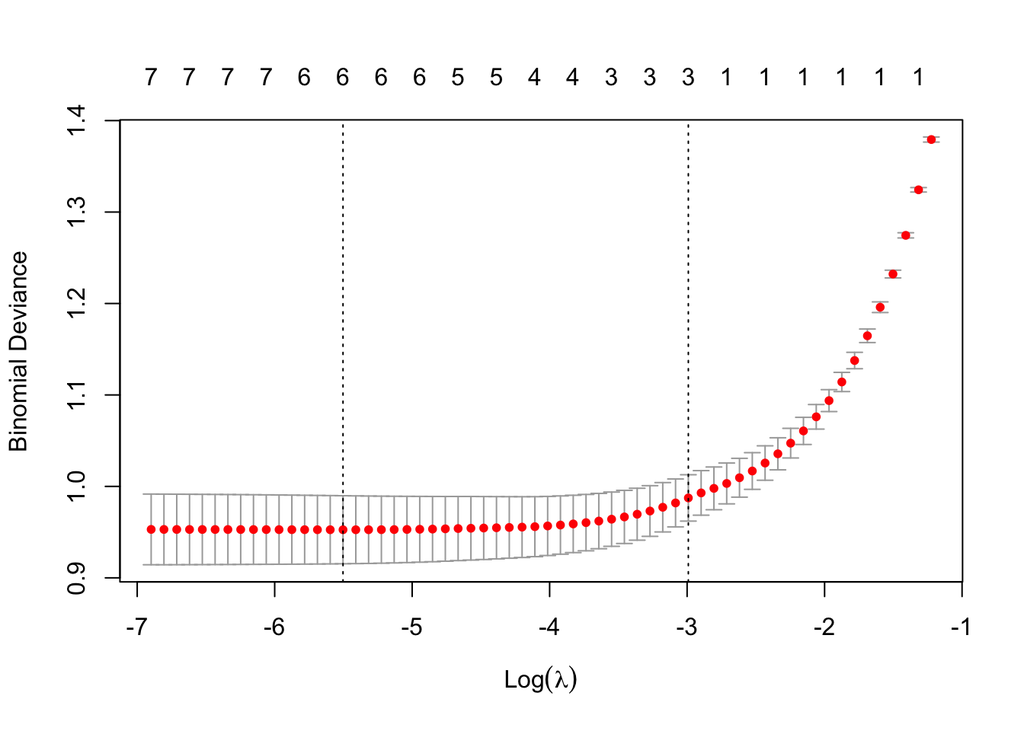

```r
set.seed(1234)

mod3_cv <- cv.glmnet(x.train, alc_consumption_train, alpha = 1,
                     family = "binomial", standardize = TRUE)
plot(mod3_cv)
```

```r
lambda_mod3 <- mod3_cv$lambda.1se

mod3 <- glmnet(x.train, alc_consumption_train, alpha = 1, family = "binomial",
               standardize = TRUE,
               lambda=mod3_cv$lambda.1se)
```

### Lasso model results and predictions.

```r
coef(mod3) # model coefficients
```

```
## 8 x 1 sparse Matrix of class "dgCMatrix"
##                                 s0
## (Intercept)             0.17272158
## neurotocism_score       .
## extroversion_score      0.02263760
## openness_score          .
## agreeableness_score     .
## conscientiousness_score .
## impulsiveness_score     1.29437601
## sens_seeking_score      0.03227442
```

```r
# Make predictions
mod3_pred <-
  mod3 %>%
  predict(x.test) %>%
  data.frame()

# compare the values to 0 because this produces estimated log(OR)
mod3_pred <-
  mod3_pred %>%
  mutate(prediction = factor(ifelse(mod3_pred > 0,"CurrentUse","NotCurrentUse"),
                            levels = c("NotCurrentUse", "CurrentUse")))

# Model prediction performance using a confusion matrix
confusion_mod3 <- confusionMatrix(mod3_pred$prediction, testing$alc_consumption, positive="CurrentUse")
confusion_mod3$table
```

```
##                Reference
## Prediction      NotCurrentUse CurrentUse
##   NotCurrentUse           147         48
##   CurrentUse               29        152
```

For this third lasso regression model, we perform cross-validation to choose the best tuning parameter for lambda to be 0.0502341. We also see that this model shrinks down the features of neurotocism, openness, agreeableness, and conscientiousness scores and contains extroversion, impulsiveness, and sensation-seeking scores.

After applying our lasso logistic regression model to the testing dataset, we find that it is 79.52% accurate in predicting alcohol consumption status, with a sensitivity and specificity of 76% and 83.52%, respectively.

# Final Model and Comments.

I would choose **the first model** using cross-validation for both alpha and lambda as my final model.

We also used cross-validation to choose both tuning parameters of alpha and lambda, whereas the third model used cross-validation to only choose lambda (Lasso implies alpha = 1) which many not be as optimal for prediction. The first prediction model is also more efficient in prediction because it has two features whereas the third model has three, and the traditional logistic regression uses all the features.

# Possible Research Questions.

A research question that this analysis could directly address is:

- What personality traits predict alcohol consumption status?

A research question that this analysis could indirectly address by providing information for a subsequent analysis is:

- Does an individual’s personality have an effect on alcohol use?
- What psychological measures can be used to predict substance use status?